**Machine Learning for Mechanical Engineering**  
**Homework 04**  
**Due Tuesday, 04/21/20 09:30 AM**

TA : Taewan Kim  
Instructor: Prof. Seungchul Lee  
http://iai.postech.ac.kr/  
Industrial AI Lab at POSTECH

# Problem 1

Suppose you receive the binary signal. The signal is corrupted with noises while transmitting through channels. We want to get rid of noise from the original signal through the $L_1$ optimization. The mathematical problem statement is given:

$$ \begin{array}{Icr}\begin{align*} y = x + \omega\\ x \in \{ 0, 1 \}\\ \omega \text{ is noise} \end{align*}\end{array} \quad \Longrightarrow \begin{array}{I} \quad \text{Recover original signal } x \text{ from corrupted signal } y \end{array} $$

## Step 1. Data generation

(a) First, generate the original signal of 200 data points as shown in the below figure. This can be simply done using ones and zeros commands in Python.

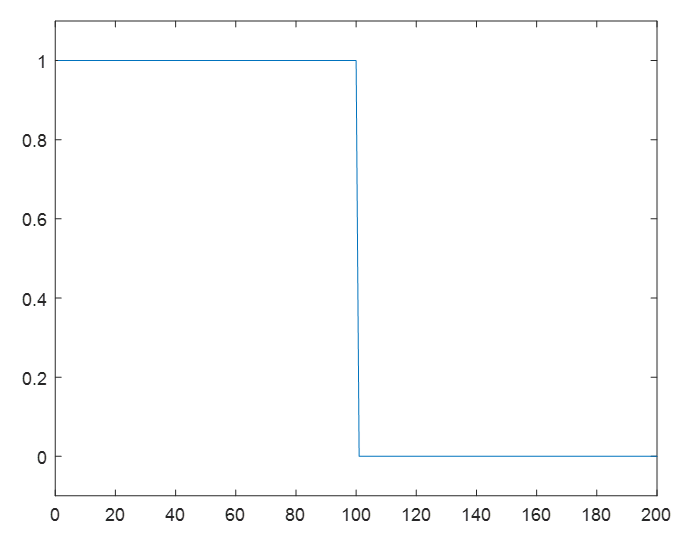

(b) Next, corrupt the original signal with Gaussian noise. This can be done using randn command in Python. One of realizations of the corrupted signal will be given:

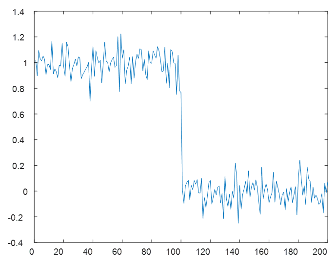

## Step 2. $L_1$ optimization

Note that the signal is sparse (in a sense of frequency domain). Therefore we can apply the $L_1$ optimization. We will optimize the $L_1$ loss function with the $L_2$ constraints.

(c) Plot the reconstructed signal. In addition, by changing the beta, explain how beta affects in an optimization process. One of reconstructed signal with a proper value of beta is shown below:

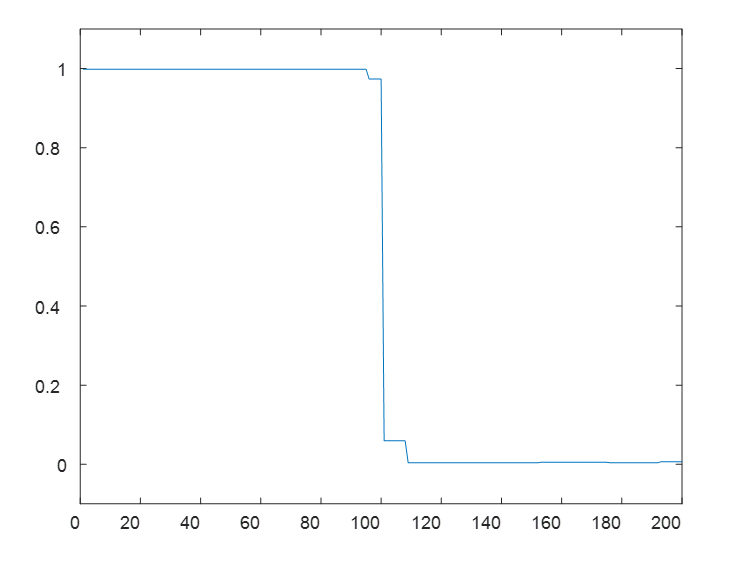

# Solution

(a) First, generate the original signal of 200 data points as shown in the below figure. This can be simply done using ones and zeros commands in Python.

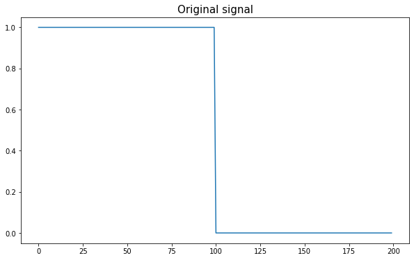

```python
import numpy as np
import cvxpy as cvx
import matplotlib.pyplot as plt
%matplotlib inline

ones = np.ones([100,1])
zeros = np.zeros([100, 1])

x = np.vstack([ones, zeros])
plt.figure(figsize = (10, 6))
plt.plot(x)
plt.title('Original signal', fontsize=15)
plt.show()
```

(b) Next, corrupt the original signal with Gaussian noise. This can be done using randn command in Python. One of realizations of the corrupted signal will be given:

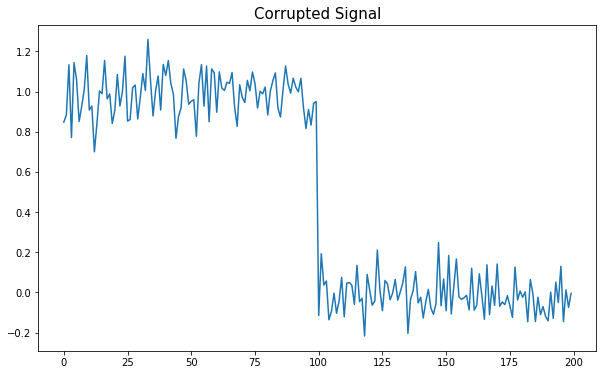

```python
x_cor = x + 0.1*np.random.randn(200, 1)

plt.figure(figsize = (10, 6))
plt.plot(x_cor)
plt.title('Corrupted Signal', fontsize=15)
plt.show()
```

(c) Plot the reconstructed signal. In addition, by changing the beta, explain how beta affects in an optimization process. One of reconstructed signal with a proper value of beta is shown below:

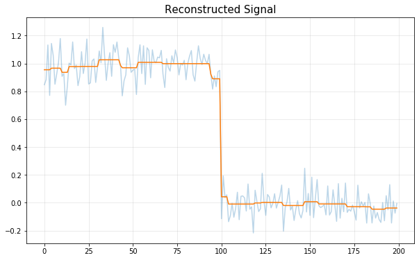

```python
# Step 2
beta = 1.3
x_hat = cvx.Variable([200, 1])
obj = cvx.Minimize(cvx.norm(x_hat[1:200] - x_hat[0:199], 1))
const = [cvx.norm(x_hat - x_cor, 2) <= beta]
prob = cvx.Problem(obj, const)
result = prob.solve()

x_hat = np.asarray(x_hat.value)

plt.figure(figsize = (10, 6))
plt.plot(x_cor, alpha = 0.3)
plt.plot(x_hat)
plt.title('Reconstructed Signal', fontsize=15)
plt.grid(alpha = 0.3)
plt.show()
```

# Problem 2

The regularized least-squares problem has the form

$$ \min_{\theta} \;\lVert A\theta -y\rVert_2^2 + \lambda \lVert \theta \rVert_2^2$$

(a) Show that the solution is given by
$$ \hat{\theta} = \left( A^T A + \lambda I_n \right)^{-1} A^T y $$

- Do not use the method of Lagrangian multipliers

(b) Write down a gradient descent algorithm for the given optimization problem.

- Hint: Note that $$ \;\lVert A\theta -y\rVert_2^2 = (A\theta - y)^T(A\theta - y)$$
  Then, you can differentiate the above equation to compute the gradient. Likewise, you can compute the gradient of the regularizer.

(c) Based on the result of (b), describe the role of regularizer term.

- Hint: Gradient $g$ is computed by $ g = g_{\text{projection}} + g_{\text{regularizer}} $.

(d) Describe results of (a) and (b) have the same meaning.

(e) Find and draw an approximated curve of the given data points below in Python using your gradient descent algorithm.

# Solution

(a) Sum of 2-norms of multiple vectors can be expressed as a 2-norm of a single vector.

$$ \begin{align*} \left\Vert A\theta - y\big\Vert^2_{2} + \big\Vert \sqrt{\lambda}I\theta-0\right\Vert^2_{2} & = \Bigg\Vert \begin{bmatrix} A\\ \sqrt{\lambda}I \end{bmatrix} \theta- \begin{bmatrix} y\\ 0 \end{bmatrix} \Bigg\Vert^2_{2} \end{align*}$$

$$ \hat{\theta} = \left( \begin{bmatrix} A\\ \sqrt{\lambda}I \end{bmatrix}^T \begin{bmatrix} A\\ \sqrt{\lambda}I \end{bmatrix}\right)^{-1}\begin{bmatrix} A\\ \sqrt{\lambda}I \end{bmatrix}^T \begin{bmatrix} y\\ 0 \end{bmatrix} = \left( A^T A + \lambda I_n \right)^{-1} A^T y $$

(b) Let $J(\theta) = \Vert A\theta - y \Vert_2^2 + \lambda \Vert \theta \Vert_2^2$. A gradient descent algorithm is formulated as the following,

$$ \theta \leftarrow \theta - \eta \frac{\partial{J}}{\partial{\theta}}. $$

Need to compute $\frac{\partial{J}}{\partial{\theta}}$.

$$ \begin{align*} g_{\text{projection}} &= \frac{\partial}{\partial{\theta}} \Vert A\theta - y \Vert_2^2 \\ &= \frac{\partial}{\partial{\theta}} (A\theta - y)^T(A\theta - y) \\ &= \frac{\partial}{\partial{\theta}} (\theta^T A^T A \theta - 2\theta^T A^T y - y^Ty) \\ &= 2A^TA \theta - 2A^Ty \\ \\ g_{\text{regularizer}} &= \frac{\partial}{\partial{\theta}} \Vert \theta \Vert_2^2 \\ &= \frac{\partial}{\partial{\theta}} \theta^T \theta \\ &= 2 \theta. \end{align*} $$

Therefore,

$$ \begin{align*} \frac{\partial{J}}{\partial{\theta}} &= g_{\text{projection}} + \lambda g_{\text{regularizer}} \\ &= 2A^TA \theta - 2A^Ty + \lambda 2 \theta. \end{align*} $$

Then, the gradient descent algorithm is formulated as the following

$$ \theta \leftarrow \theta - \eta(2A^TA \theta - 2A^Ty + \lambda 2 \theta). $$

(c)

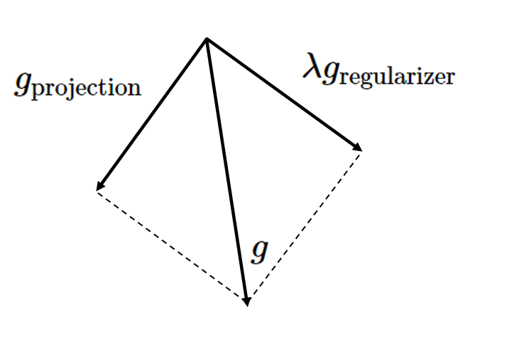

$g_{\text{regularizer}}$ make $\theta$ converge to zero. Since $g = g_{\text{projection}} + \lambda g_{\text{regularizer}}$, we can see that regularizer underestimates the value of the projection.

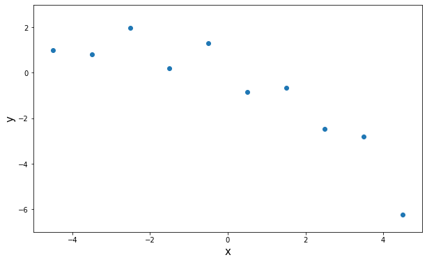

```python
import numpy as np
import matplotlib.pyplot as plt

x = np.linspace(-4.5, 4.5, 10)
y = np.array([0.9819, 0.7973, 1.9737, 0.1838, 1.3180, -0.8361, -0.6591, -2.4701, -2.8122, -6.2512])

plt.figure(figsize=(10, 6))
plt.plot(x, y, 'o')
plt.xlabel('x', fontsize=15)
plt.ylabel('y', fontsize=15)
plt.xlim(-5, 5)
plt.ylim(-7, 3)
plt.show()
```

```python
m = np.shape(x)[0]
x = np.reshape(x,(-1,1))
y = np.reshape(y,(-1,1))

X = np.hstack([np.ones([m,1]), x, x**2, x**3, x**4, x**5])
X = np.asmatrix(X)
y = np.asmatrix(y)

theta = np.ones([6,1])
lamda = 1
alpha = 1e-7
n_iter = 100000

for i in range(n_iter):
    g = 2*X.T*X*theta - 2*X.T*y + 2*lamda*theta
    theta = theta - alpha*g

print(theta)
```

```
[[ 0.75330967]
 [ 0.6793209 ]
 [ 0.02933984]
 [-0.20172918]
 [-0.0104212 ]
 [ 0.00646841]]
```

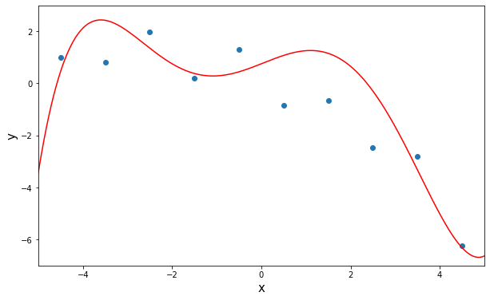

```python
xp = np.linspace(-5,5,1000)
yp = theta[0,0] + theta[1,0]*xp + theta[2,0]*xp**2 + theta[3,0]*xp**3 + \
     theta[4,0]*xp**4 + theta[5,0]*xp**5

plt.figure(figsize = (10,6))
plt.plot(x,y, 'o')
plt.plot(xp,yp, 'r')
plt.xlabel('x', fontsize = 15)
plt.ylabel('y', fontsize = 15)
plt.xlim(-5,5)
plt.ylim(-7,3)
plt.show()
```

# Problem 3

TensorFlow library provides hand-written digits data (MNIST dataset). You will use this hand-written digits to solve nonlinear regression problem.

(a) Plot the column's mean pixel value from digit zero to nine.

```python
import warnings
warnings.simplefilter(action='ignore', category=FutureWarning)

import matplotlib.pyplot as plt
import numpy as np

import tensorflow as tf
from tensorflow.examples.tutorials.mnist import input_data

mnist = input_data.read_data_sets("MNIST_data/", one_hot=False, reshape=True)

print(mnist.train.images.shape, mnist.train.labels.shape)
```

[output not shown]

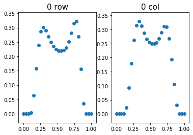

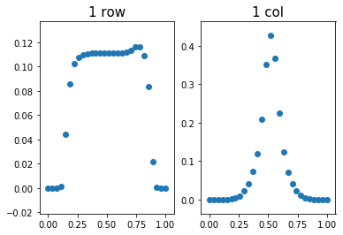

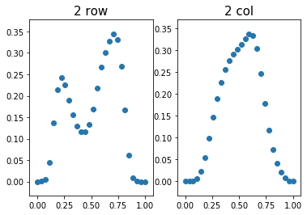

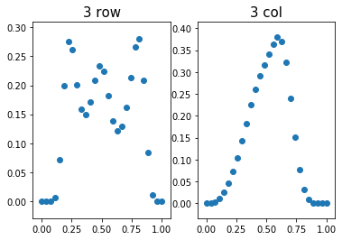

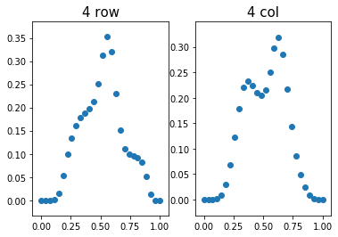

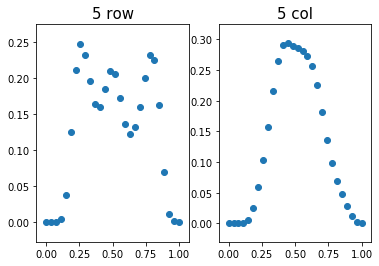

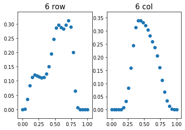

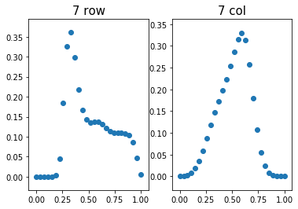

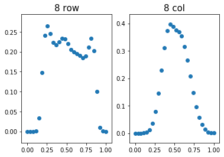

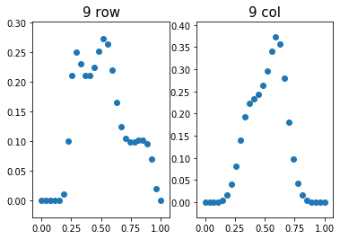

```python
row_digit = []
col_digit = []
for i in range(10):
    label_index = np.where(mnist.train.labels == i)
    data = mnist.train.images[label_index].reshape((-1, 28,28))
    row_mean = np.mean(data , axis = (0,2))
    column_mean = np.mean(data , axis = (0,1))

    plt.subplot(1,2,1)
    plt.title(str(i) + ' row', fontsize = 15)
    plt.scatter(np.linspace(0, 1, 28), row_mean)

    plt.subplot(1,2,2)
    plt.title(str(i) + ' col', fontsize = 15)
    plt.scatter(np.linspace(0, 1, 28), column_mean)
    plt.show()
    row_digit.append(row_mean)
    col_digit.append(column_mean)
```

(b) Draw an approximated curve of the given data in Python using polynomial functions. You are supposed to draw 10 graphs for each digit.

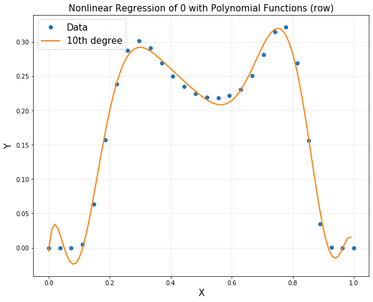

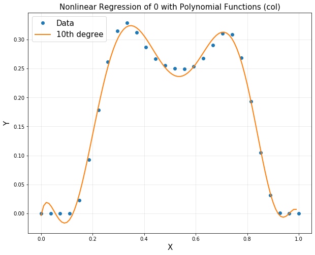

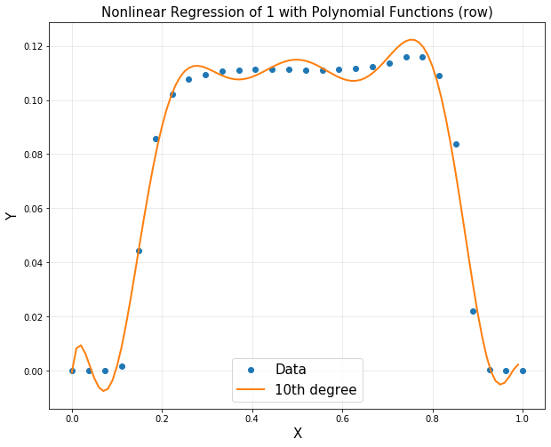

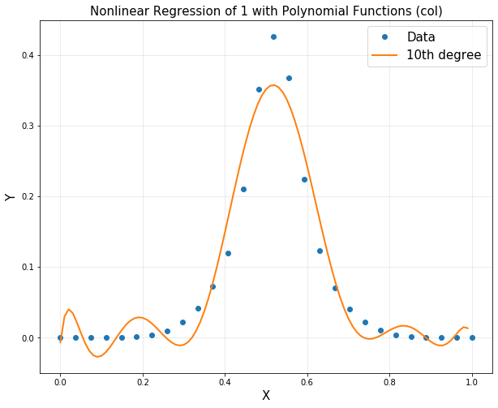

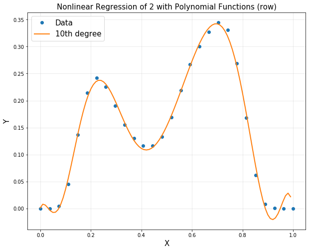

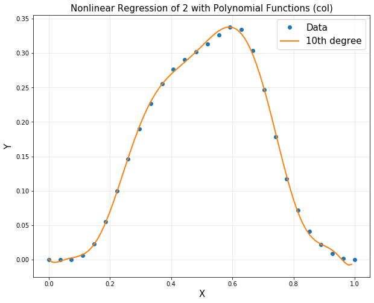

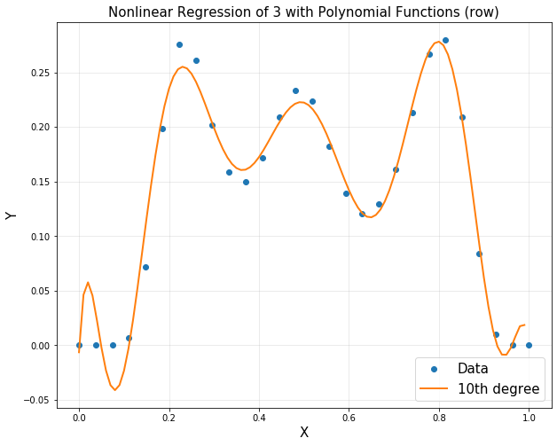

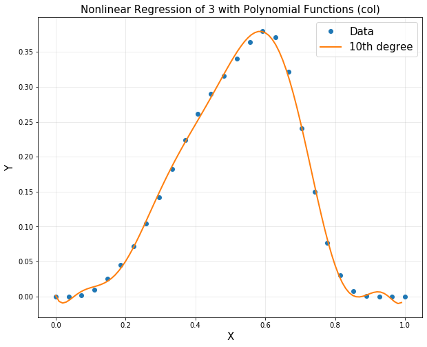

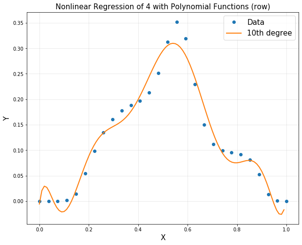

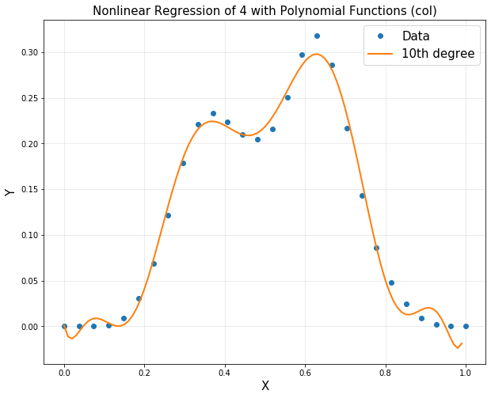

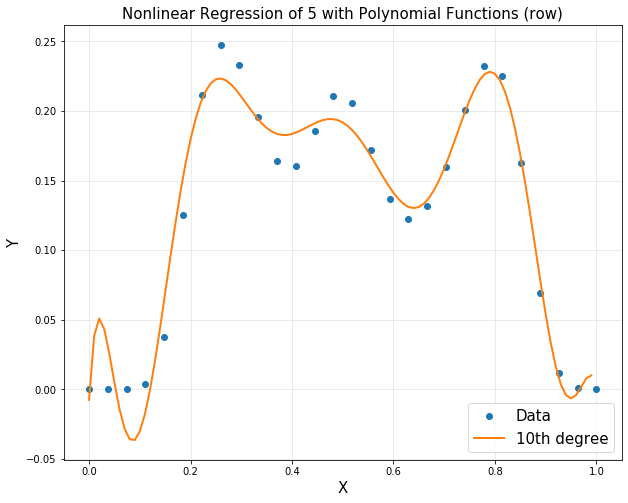

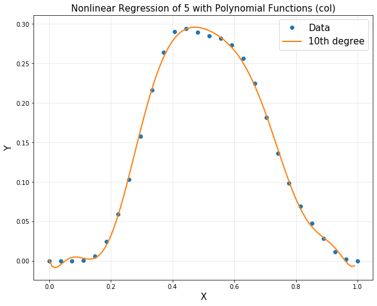

[8 more figures not shown]

```python
for num in range(10):
    row_y = row_digit[num].reshape(-1,1)
    col_y = col_digit[num].reshape(-1,1)
    x = np.linspace(0, 1,28).reshape(-1,1)
    A = np.hstack([x**i for i in range(11)])
    A = np.asmatrix(A)

    row_theta = (A.T*A).I*A.T*row_y
    col_theta = (A.T*A).I*A.T*col_y
    # to plot
    xp = np.arange(0, 1, 0.01).reshape(-1, 1)

    polybasis = np.hstack([xp**i for i in range(11)])
    polybasis = np.asmatrix(polybasis)

    row_yp = polybasis*row_theta
    col_yp = polybasis*col_theta


    plt.figure(figsize = (10, 8))
    plt.plot(x, row_y, 'o', label = 'Data')
    plt.plot(xp[:,0], row_yp[:,0], linewidth = 2, label = '10th degree')
    plt.title('Nonlinear Regression of '+ str(num) + ' with Polynomial Functions (row)', fontsize = 15)
    plt.xlabel('X', fontsize = 15)
    plt.ylabel('Y', fontsize = 15)
    plt.legend(fontsize = 15)
    plt.grid(alpha = 0.3)

    plt.figure(figsize = (10, 8))
    plt.plot(x, col_y, 'o', label = 'Data')
    plt.plot(xp[:,0], col_yp[:,0], linewidth = 2, label = '10th degree')
    plt.title('Nonlinear Regression of '+ str(num) + ' with Polynomial Functions (col)', fontsize = 15)
    plt.xlabel('X', fontsize = 15)
    plt.ylabel('Y', fontsize = 15)
    plt.legend(fontsize = 15)
    plt.grid(alpha = 0.3)
plt.show()
```

(c) Draw an approximated curve of the given data in Python using RBF functions. You are supposed to draw 10 graphs for each digit.